# Introduction to R Programming

Tajudeen Abdulazeez

5/19/2023

## Introduction to R

RStudio requires R 2.11.1 (or higher). Download and install R first Then download and install R studio

We will be going through this step by step in the session.

### GETTING R AND R STUDIO

Links:

- https://www.r-project.org/
- https://www.rstudio.com/
- https://www.rstudio.com/resources/webinars/getting-your-data-into-r/
- https://www.rstudio.com/products/rstudio/download/

### USING R

USING KNOWN AND FREE DATASETS

R offers many datasets that can be used to practice with. R dataset information and examples are located here: https://stat.ethz.ch/R-manual/R-devel/library/datasets/html/00Index.html R Studio installs with the R “datasets” Package. To use it, type (or include in your code) the statement: library(datasets)

```r
library(datasets)

head(cars)
```

```
##   speed dist
## 1     4    2
## 2     4   10
## 3     7    4
## 4     7   22
## 5     8   16
## 6     9   10
```

```r
head(iris)
```

```
##   Sepal.Length Sepal.Width Petal.Length Petal.Width Species
## 1          5.1         3.5          1.4         0.2  setosa
## 2          4.9         3.0          1.4         0.2  setosa
## 3          4.7         3.2          1.3         0.2  setosa
## 4          4.6         3.1          1.5         0.2  setosa
## 5          5.0         3.6          1.4         0.2  setosa
## 6          5.4         3.9          1.7         0.4  setosa
```

#### PULLING DATA INTO YOUR R PROGRAM

```r
(x <- 1:10)  #This will set x as an array from 1 to 10 and will print it.
```

```
##  [1]  1  2  3  4  5  6  7  8  9 10
```

```r
(y <- 21:30)
```

```
##  [1] 21 22 23 24 25 26 27 28 29 30
```

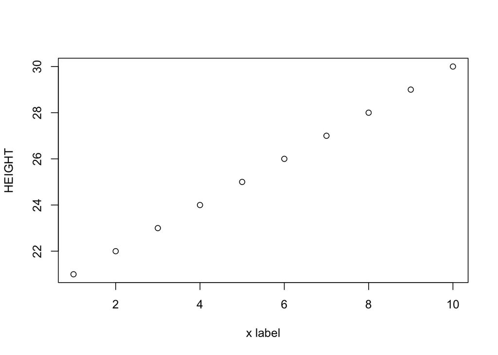

```r
plot(x,y, xlab="x label", ylab="HEIGHT")
```

```r
print("Hello")
```

```
## [1] "Hello"
```

```r
(x[3])
```

```
## [1] 3
```

```r
print(x[0])
```

```
## integer(0)
```

```r
(p <- rep(3,9))
```

```
## [1] 3 3 3 3 3 3 3 3 3
```

```r
(length(p))
```

```
## [1] 9
```

```r
(mean(p))
```

```
## [1] 3
```

#### REP AND SEQ

```r
(q<-rep("TRUE",3))
```

```
## [1] "TRUE" "TRUE" "TRUE"
```

```r
(y<-seq(from=1, to=9, by=2))
```

```
## [1] 1 3 5 7 9
```

```r
(z<-seq(11,23,3))
```

```
## [1] 11 14 17 20 23
```

```r
(x<-c(2.2, 3.0, 6.7))
```

```
## [1] 2.2 3.0 6.7
```

```r
w<-c(3.1, 5.5, 8.7, 9.9)
w[3]
```

```
## [1] 8.7
```

```r
min(w)
```

```
## [1] 3.1
```

```r
max(w)
```

```
## [1] 9.9
```

```r
sort(w)
```

```
## [1] 3.1 5.5 8.7 9.9
```

```r
(s1<-rep(w,times=2))
```

```
## [1] 3.1 5.5 8.7 9.9 3.1 5.5 8.7 9.9
```

```r
(s2 <- rep(w,each=2))
```

```
## [1] 3.1 3.1 5.5 5.5 8.7 8.7 9.9 9.9
```

#### CREATE A MATRIX: RBIND AND CBIND

```r
d1 <- c(0, 1, 3, 5, 9)
d2<- c(3, 6, 0, 34, 67)
(rbind(d1,d2))
```

```
##    [,1] [,2] [,3] [,4] [,5]
## d1    0    1    3    5    9
## d2    3    6    0   34   67
```

```r
(cbind(d1,d2))
```

```
##      d1 d2
## [1,]  0  3
## [2,]  1  6
## [3,]  3  0
## [4,]  5 34
## [5,]  9 67
```

#### DATAFRAMES

```r
#dataframes
#a list with elements of diff modes (types)
(df <- list("apple", 7, TRUE, "fred", 5.5))
```

```
## [[1]]
## [1] "apple"
##
## [[2]]
## [1] 7
##
## [[3]]
## [1] TRUE
##
## [[4]]
## [1] "fred"
##
## [[5]]
## [1] 5.5
```

```r
(mode(df))
```

```
## [1] "list"
```

```r
#sapply - apply a particpular function to #each element
(sapply(df,mode))
```

```
## [1] "character" "numeric"   "logical"   "character" "numeric"
```

#### USING “C” (CONCAT) VERSUS “LIST”

Creating an array using “c” will require that all items in the array are the SAME TYPE. Lists do not have to be of the same type

```r
#c vs list
(f <- c(5, 7, "dog", 9))
```

```
## [1] "5"   "7"   "dog" "9"
```

```r
# Because concat defaults it will make all #chars
#list allows a collections of different modes
#or types
(g <- list(5, 7, "dog", 9))
```

```
## [[1]]
## [1] 5
##
## [[2]]
## [1] 7
##
## [[3]]
## [1] "dog"
##
## [[4]]
## [1] 9
```

```r
(sapply(f,mode))
```

```
##           5           7         dog           9
## "character" "character" "character" "character"
```

```r
(sapply(g,mode))
```

```
## [1] "numeric"   "numeric"   "character" "numeric"
```

#### EXAMPLE: MAKING A DATAFRAME

```r
(df1 <- data.frame(book=c("B1", "B2", "B3"), author=c("A1", "A2", "A3"), year=c(1950, 2005, 1999), used=c(TRUE, FALSE, TRUE)))
```

```
##   book author year  used
## 1   B1     A1 1950  TRUE
## 2   B2     A2 2005 FALSE
## 3   B3     A3 1999  TRUE
```

```r
(df1[1,2])
```

```
## [1] "A1"
```

```r
#dataframes can be made column by column
```

#### DATAFRAME LARGER EXAMPLE: AARDVARKS

```r
aardvarkdata<-data.frame(individual=1:10, country=c(rep("Kenya",6), rep("Tanzania",4)), litter=c(2, 3, 4, 2, 3, 4, 2, 3, 1, 3))

print(aardvarkdata)
```

```
##    individual  country litter
## 1           1    Kenya      2
## 2           2    Kenya      3
## 3           3    Kenya      4
## 4           4    Kenya      2
## 5           5    Kenya      3
## 6           6    Kenya      4
## 7           7 Tanzania      2
## 8           8 Tanzania      3
## 9           9 Tanzania      1
## 10         10 Tanzania      3
```

```r
aardvarkdata$litter
```

```
##  [1] 2 3 4 2 3 4 2 3 1 3
```

```r
aardvarkdata$country
```

```
##  [1] "Kenya"    "Kenya"    "Kenya"    "Kenya"    "Kenya"    "Kenya"
##  [7] "Tanzania" "Tanzania" "Tanzania" "Tanzania"
```

```r
aardvarkdata[,3]
```

```
##  [1] 2 3 4 2 3 4 2 3 1 3
```

```r
# All rows, columns 1 and 2
aardvarkdata[,1:2]
```

```
##    individual  country
## 1           1    Kenya
## 2           2    Kenya
## 3           3    Kenya
## 4           4    Kenya
## 5           5    Kenya
## 6           6    Kenya
## 7           7 Tanzania
## 8           8 Tanzania
## 9           9 Tanzania
## 10         10 Tanzania
```

#### ADD A NEW COLUMN (MEANWEIGHT) TO DATAFRAME

```r
aardvarkdata$meanWeight<-c(30, 29, 31, 32, 34, 32, 34, 45, 34, 23)
print(aardvarkdata,row.names = FALSE)
```

```
##  individual  country litter meanWeight
##           1    Kenya      2         30
##           2    Kenya      3         29
##           3    Kenya      4         31
##           4    Kenya      2         32
##           5    Kenya      3         34
##           6    Kenya      4         32
##           7 Tanzania      2         34
##           8 Tanzania      3         45
##           9 Tanzania      1         34
##          10 Tanzania      3         23
```

#### PHYSICALLY IMPORTING DATA IN R STUDIO

```r
MyData <- read.csv(file="/Users/teejay/dev/courses/machine-learning-in-r/data/SalesData.csv")
(head(MyData)) #prints the first 6 rows and the headers
```

```
##   Region Store Mon Tue Wed Thu Fri Sat Sun
## 1      A    S1 100 125 119 110 116  59  57
## 2      A    S2  50  65  67  78  54  42  45
## 3      B    S3  78  89  81  92  97  82  85
## 4      B    S4  90 120 105  97 107 119 120
## 5      B    S5  99 133 120 115 137 126 100
## 6      C    S6 130 190 211 200 187 187 195
```

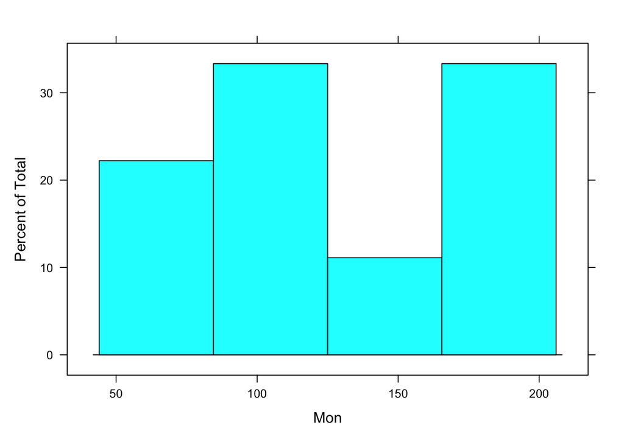

```r
#Can also use read.table(read.csv(file="C:/Users/Ami/Desktop/nySMALL.csv", sep="\t", header=TRUE)
#Can Also allow the User to Choose the file as the R code runs:
#AirData <- read.table(file.choose(), sep="\t", header=TRUE)
#It is also possible to directly read the HTML code from a website
#sitedata <- read.scv("http://www.mathandstatistics.com")
Store <- MyData$Store

Mon <- MyData$Mon


library(lattice)
histogram(Mon)
```

```r
tail(MyData)
```

```
##   Region Store Mon Tue Wed Thu Fri Sat Sun
## 4      B    S4  90 120 105  97 107 119 120
## 5      B    S5  99 133 120 115 137 126 100
## 6      C    S6 130 190 211 200 187 187 195
## 7      C    S7 168 176 170 200 220 215 300
## 8      D    S8 200 210 190 195 187 170 175
## 9      D    S9 190 185 195 170 189 172 200
```

```r
nrow(MyData)
```

```
## [1] 9
```

```r
ncol(MyData)
```

```
## [1] 9
```

#### GETTING NEW PACKAGES

- install.packages(‘package_name’)

#### USING R DATASETS: AIRQUALITY

```r
#Air Quality
mydata<-airquality

(head(mydata))
```

```
##   Ozone Solar.R Wind Temp Month Day
## 1    41     190  7.4   67     5   1
## 2    36     118  8.0   72     5   2
## 3    12     149 12.6   74     5   3
## 4    18     313 11.5   62     5   4
## 5    NA      NA 14.3   56     5   5
## 6    28      NA 14.9   66     5   6
```

```r
(tail(mydata))
```

```
##     Ozone Solar.R Wind Temp Month Day
## 148    14      20 16.6   63     9  25
## 149    30     193  6.9   70     9  26
## 150    NA     145 13.2   77     9  27
## 151    14     191 14.3   75     9  28
## 152    18     131  8.0   76     9  29
## 153    20     223 11.5   68     9  30
```

#### WRITING TO A DATAFILE FROM R

```r
MyData <- read.csv(file="/Users/teejay/dev/courses/machine-learning-in-r/data/SalesData.csv")
(head(MyData))
```

```
##   Region Store Mon Tue Wed Thu Fri Sat Sun
## 1      A    S1 100 125 119 110 116  59  57
## 2      A    S2  50  65  67  78  54  42  45
## 3      B    S3  78  89  81  92  97  82  85
## 4      B    S4  90 120 105  97 107 119 120
## 5      B    S5  99 133 120 115 137 126 100
## 6      C    S6 130 190 211 200 187 187 195
```

```r
Region <- MyData$Region
write.csv(Region, file="/Users/teejay/dev/courses/machine-learning-in-r/data/NewRFile.txt")
```

#### LOOKING AT DATA

- Looking at raw data: head, tail, class, levels, and view
- What type of data object is the data stored in: vector/matrix, dataframe, list, etc.
- What are properties of the data: nrow(), ncol(), length(), names(), str(), dplyr::glimpse()
- Visualize (basic) the data: plot(), identity()
- Summarize the data: xtab()

#### LOOKING AT THE DATA

```r
#Must first install.packages("dplyr") on console
library(dplyr)
AirData <- airquality
(head(AirData))
```

```
##   Ozone Solar.R Wind Temp Month Day
## 1    41     190  7.4   67     5   1
## 2    36     118  8.0   72     5   2
## 3    12     149 12.6   74     5   3
## 4    18     313 11.5   62     5   4
## 5    NA      NA 14.3   56     5   5
## 6    28      NA 14.9   66     5   6
```

```r
(tail(AirData))
```

```
##     Ozone Solar.R Wind Temp Month Day
## 148    14      20 16.6   63     9  25
## 149    30     193  6.9   70     9  26
## 150    NA     145 13.2   77     9  27
## 151    14     191 14.3   75     9  28
## 152    18     131  8.0   76     9  29
## 153    20     223 11.5   68     9  30
```

```r
(class(AirData))
```

```
## [1] "data.frame"
```

```r
(length(AirData))  # number of columns
```

```
## [1] 6
```

```r
(ncol(AirData))  # same as length
```

```
## [1] 6
```

```r
(names(AirData))  #col names
```

```
## [1] "Ozone"   "Solar.R" "Wind"    "Temp"    "Month"   "Day"
```

```r
(nrow(AirData))
```

```
## [1] 153
```

```r
((AirData[10,4]))  #[rows,columns]
```

```
## [1] 69
```

```r
#(View(AirData))  #"V" must be uppercase

#if larger than 1000 rows, view will only #write first 1000
(str(AirData))   #summarize the data
```

```
## 'data.frame':    153 obs. of  6 variables:
##  $ Ozone  : int  41 36 12 18 NA 28 23 19 8 NA ...
##  $ Solar.R: int  190 118 149 313 NA NA 299 99 19 194 ...
##  $ Wind   : num  7.4 8 12.6 11.5 14.3 14.9 8.6 13.8 20.1 8.6 ...
##  $ Temp   : int  67 72 74 62 56 66 65 59 61 69 ...
##  $ Month  : int  5 5 5 5 5 5 5 5 5 5 ...
##  $ Day    : int  1 2 3 4 5 6 7 8 9 10 ...
```

```r
(levels(AirData))  #
```

[output not shown]

```r
#(glimpse(AirData))
```

#### STARTING TO CLEAN UP THE DATA

```r
#Change Month to variable to a factor (not an int)
AirData$Month <- factor(AirData$Month)

(levels(AirData$Month))
```

```
## [1] "5" "6" "7" "8" "9"
```

```r
#Change the names of the levels
levels(AirData$Month)<- list(May="5", June="6", July="7", Aug="8", Sept="9")
(levels(AirData$Month))
```

```
## [1] "May"  "June" "July" "Aug"  "Sept"
```

```r
#(glimpse(AirData))
```

#### VISUALIZING

```r
plot(AirData$Ozone,AirData$Temp)
```

[output not shown]

#### USING IDENTIFY

```r
plot(AirData$Ozone,AirData$Temp)
## identify makes the plot interactive - as you #click
# points are saved. Must press "finish" at the #top of the plot
# identify will then label the dta points clicked.
idx<-identify(AirData$Ozone, AirData$Temp)
```

#### IDENTIFY WITH IMPROVED LABELS

```r
## Get the Day for each datapoint
# Here, first paste together the char #version of the day with _ and the char
#version of the month. Use this to label #all points clicked.
plot(AirData$Ozone,AirData$Temp)
idx<- identify(AirData$Temp, labels = paste(as.character(AirData$Day),"-",as.character(AirData$Month)), plot=TRUE)
```

#### XTAB

```r
## xtabs is a function that will investigate
#Is there an even distribution of data labels
## It is a formula/function so we use the ~
## It will COUNT the number of investigates for each label in dataset
xtabs(~Month, data=AirData)
```

```
## Month
##  May June July  Aug Sept
##   31   30   31   31   30
```

#### References

R Refresher by Dr. Ami Gates Associate Professor, Georgetown University drgates@georgetown.edu